# AML_Lab3_Group8

Hyungyum Kim, Milda Poceviciute, Boxi Zhang, Fanny Karelius

2018 - 10 - 8

## Question 1

A State Space Model was implemented with the following features:

*Transition model*:
$$p(z_t|z_{t-1})=\frac{1}{3}[N(z_t|z_{t-1},1)+N(z_t|z_{t-1}+1,1)+N(z_t|z_{t-1}+2,1)]$$

*Emission model*:
$$p(x_t|z_{t})=\frac{1}{3}[N(x_t|z_{t},1)+N(x_t|z_{t}+1,1)+N(x_t|z_{t}-1,1)]$$

*Initial model*:
$$p(z_1)=Uniform(0,100)$$
The functions are as follows:

```r
# M - number of particals
# Iter - number of time steps T
# z is latent variable
# x is the observation

# Function for sampling from a mixture model
sampleMix <- function(mean1,mean2,mean3,sdX){
   u <- sample(1:3,1)
   means <- c(mean1,mean2,mean3)
   return(rnorm(1,mean=means[u],sd=sdX))
}

## Function that creates the SSM model
create_SSM <- function(z0,TT, sdX=1){
    Zt <- c(z0)

    Xt <- sampleMix(mean1=z0,mean2=(z0-1),mean3=(z0+1),sd=1)

    for (i in 2:TT){
        Zt[i] <- sampleMix(mean1=Zt[i-1],mean2=(Zt[i-1]+1),mean3=(Zt[i-1]+2),sdX=1)
        Xt[i] <- sampleMix(mean1=Zt[i],mean2=(Zt[i]-1),mean3=(Zt[i]+1),sdX=sdX)
    }
    return(list(sates=Zt,observations=Xt))

}

generateX <- function(Zt, TT, sdX=1){
  Xt <- c()
  for (i in 1:TT){
    Xt[i] <-  sampleMix(mean1=Zt[i],mean2=(Zt[i]-1),mean3=(Zt[i]+1),sdX=sdX)
  }
  return(Xt)
}

## Particle filter function
particles <- function(Obs, M,Iter, sdX=1, correction=TRUE){
    Xt <- Obs

    #Initialise particles for the latent variable
    Zt <- matrix(ncol=Iter,nrow=M)
    wt <- matrix(ncol=Iter,nrow=M)
    Zt_bar <- matrix(ncol=Iter,nrow=M)
    #fill the initial time step
    Zt[,1] <- runif(M,0,100)
    # Add arbitrary values in order for the indexing to work later
    Zt_bar[,1] <- rep.int(1,M)
    wt[,1] <- rep.int(1,M)

    for (t in 2:Iter){
        # Prediction
        for (m in 1:M){
            # sample from the transition model (current Z_t depends on the Z_{t-1})
            Zt_bar[m,t] <- sampleMix(mean1=Zt[m,t-1],mean2=(Zt[m,t-1]+1),mean3=(Zt[m,t-1]+2),sdX=1)
            #Calculate weights
            wt[m,t] <- (dnorm(Xt[t],mean=Zt_bar[m,t],sd=sdX)+
                        dnorm(Xt[t],mean=(Zt_bar[m,t]-1),sd=sdX)+
                        dnorm(Xt[t],mean=(Zt_bar[m,t]+sdX),sd=1))/3
        }
        # Correction
        if (correction){
            Zt[,t]<- sample(Zt_bar[,t], M, replace = TRUE, prob = wt[,t])
        }else{
            Zt[,t] <- Zt_bar[,t]
        }

    }
    return(list(Zt=Zt,Zt_bar=Zt_bar,wt=wt))

}
```

Afterwards the states $z_{1:T}$ (using the initial and transition models) and observations $x_{1:T}$ of sensor readings (using the emission model) were simulated for $T=100$ time steps. The observations were used in the particle filter algorithm with 100 particles in order to predict the possible states (location of the robot).

We chose time points $t=$1, 35, 75, and 100 for which we plot the distribution of the particles (histograms), and indicate on them what is the true value of the $z_t$ and the expected value at that particular time step.

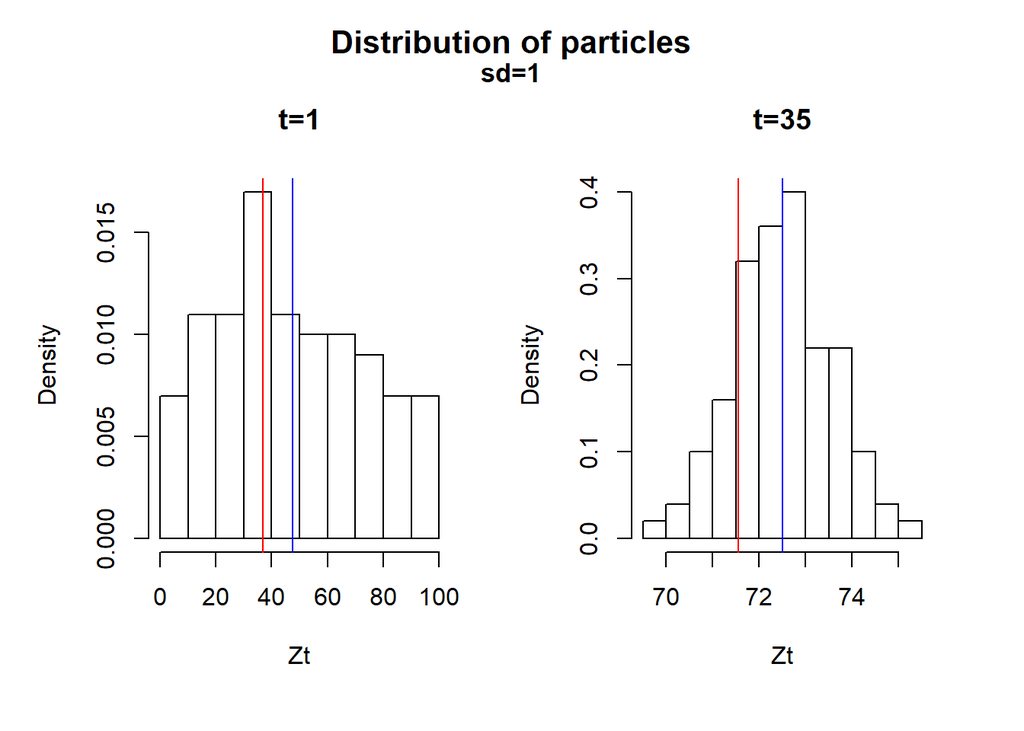

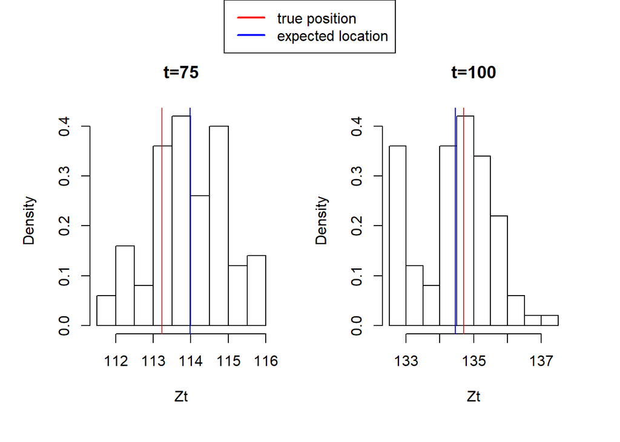

From the histograms, we conclude that the particle algorithm worked pretty well when the standard deviation was 1. In all four plots, the red line falls on one of the highest bars: this indicates that the algorithm quite accurately predicted the robots location (with a reasonable error).

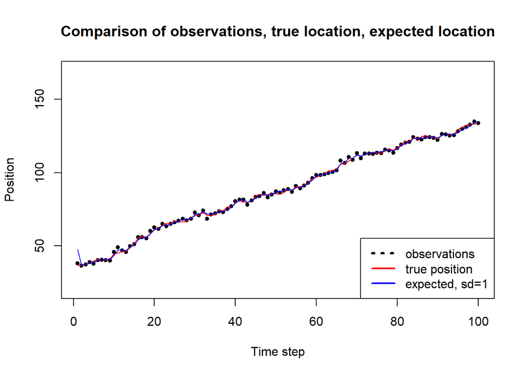

The plot above shows the average of particles in each time step, the corresponding actual state and observations. We can see that the true position and predicted positions are very close to each other, so the prediction seems to be very accurate.

## Question 2

In this question the SSM was modified by changing the emission models. Firstly, the standard deviation was set to 5, and later it was increased to 50. The states $z_{1:T}$ were kept from Question 1, but new observations $x_{1:T}$ were generated. The particle filter algorithm was applied to the two new sets of observations.

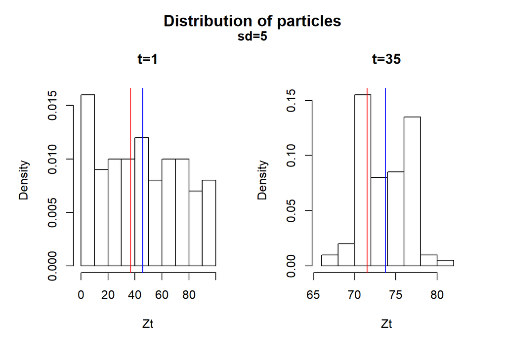

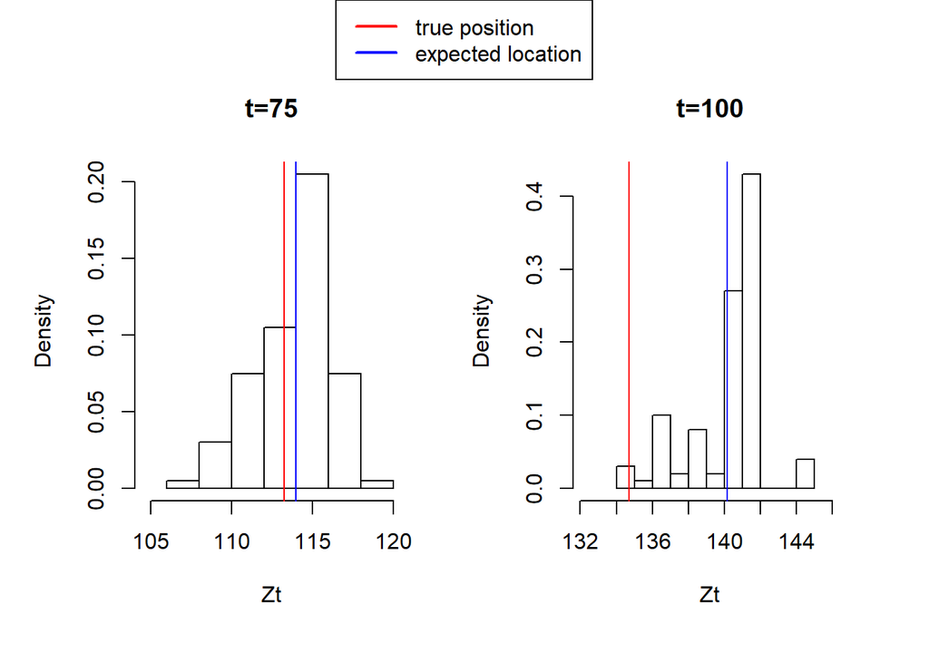

The histogram plots above show the distribution of the particles when standard deviation is 5 (for time steps 1, 35, 75, and 100). This time the algorithm performed worse: at time step 100 the true location of the robot falls into one of the shortest bars of the distribution. This indicates that the algorithm predicted a quite low probability that $z_100$ is the true value. However, the overall performance cannot be deduced by looking at only 4 time points: each new step introduces some new uncertainty, and the results at it might be worse then the results from the previous time step.

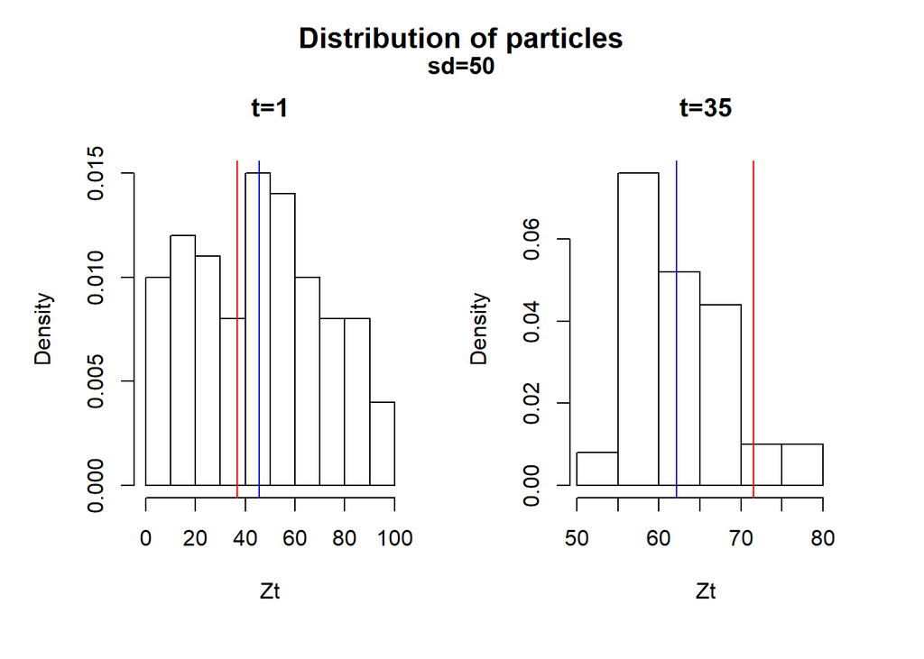

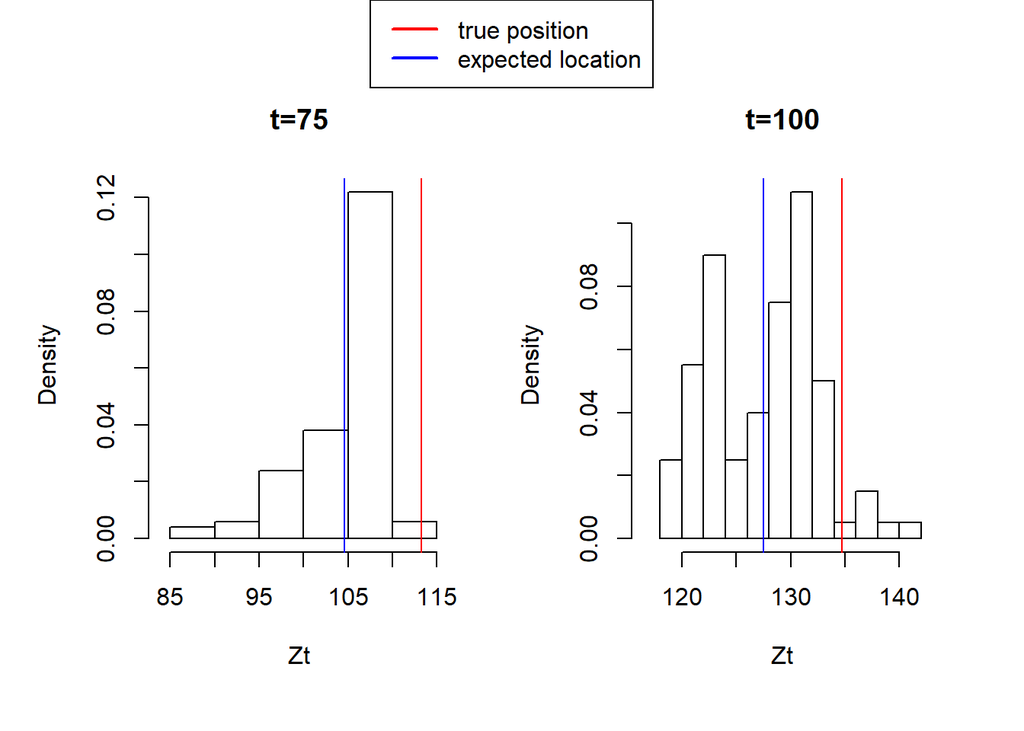

The histogram plots above show the distribution of the particles when standard deviation is 50 (for time steps 1, 35, 75, and 100). This time the true location of the robot for time steps 35, 75, and 100 falls into one of the shortest bars of the distribution of that time step. This indicates that the algorithm predicted a quite low probability that $z_t$ is the true value. It is reasonable to assume that the performance of the particle filter worsens as the standard deviation of the observations from the true states is increased: there is more uncertainty involved.

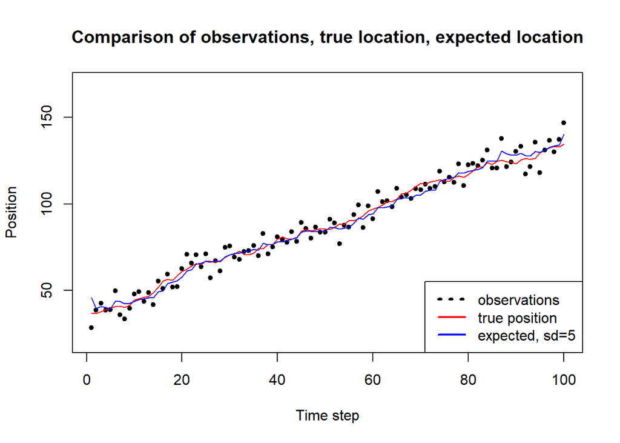

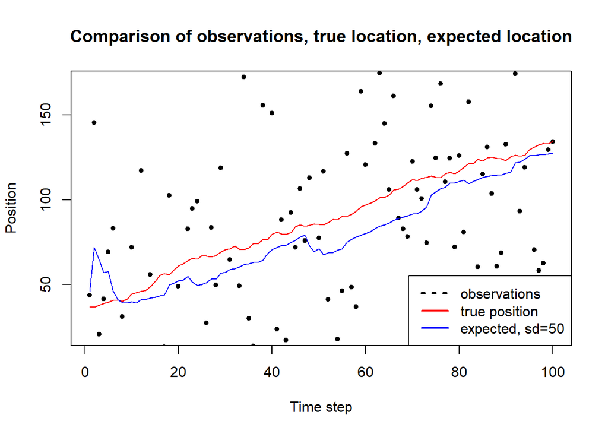

From the plots above, the observations and expected location deviate more from the true position when the standard deviation is 50 than they did when standard deviation was 5. This is because $sd=50$ adds even more uncertainty to the observations and thus the expected location than $sd=5$.

## Question 3

Question 1 was repeated without correction, i.e. importance weights were always equal to 1.

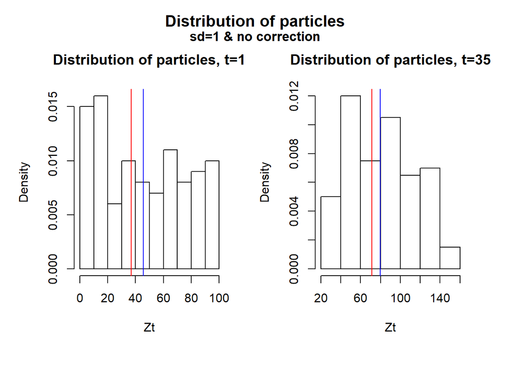

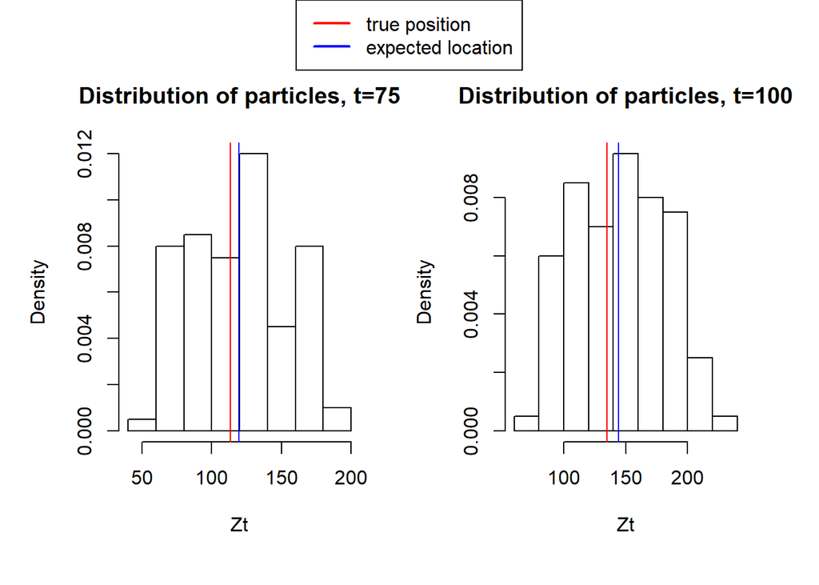

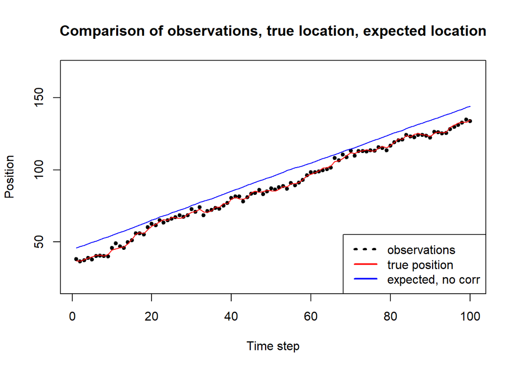

Without correction, the expected location follows a straight line. It resembles a linear regression. Without correction, unlikely particles continues to the next time step. With correction, unlikely particles are less likely to be selected to continue to the next time step and therefore the expected location will deviate less from the true position.

# Appendix

```r
knitr::opts_chunk$set(echo = FALSE,tidy.opts=list(width.cutoff=60),tidy=TRUE)
set.seed(987654321)
# M - number of particals
# Iter - number of time steps T
# z is latent variable
# x is the observation

# Function for sampling from a mixture model
sampleMix <- function(mean1,mean2,mean3,sdX){
   u <- sample(1:3,1)
   means <- c(mean1,mean2,mean3)
   return(rnorm(1,mean=means[u],sd=sdX))
}

## Function that creates the SSM model
create_SSM <- function(z0,TT, sdX=1){
    Zt <- c(z0)

    Xt <- sampleMix(mean1=z0,mean2=(z0-1),mean3=(z0+1),sd=1)

    for (i in 2:TT){
        Zt[i] <- sampleMix(mean1=Zt[i-1],mean2=(Zt[i-1]+1),mean3=(Zt[i-1]+2),sdX=1)
        Xt[i] <- sampleMix(mean1=Zt[i],mean2=(Zt[i]-1),mean3=(Zt[i]+1),sdX=sdX)
    }
    return(list(sates=Zt,observations=Xt))

}

generateX <- function(Zt, TT, sdX=1){
  Xt <- c()
  for (i in 1:TT){
    Xt[i] <-  sampleMix(mean1=Zt[i],mean2=(Zt[i]-1),mean3=(Zt[i]+1),sdX=sdX)
  }
  return(Xt)
}

## Particle filter function
particles <- function(Obs, M,Iter, sdX=1, correction=TRUE){
    Xt <- Obs

    #Initialise particles for the latent variable
    Zt <- matrix(ncol=Iter,nrow=M)
    wt <- matrix(ncol=Iter,nrow=M)
    Zt_bar <- matrix(ncol=Iter,nrow=M)
    #fill the initial time step
    Zt[,1] <- runif(M,0,100)
    # Add arbitrary values in order for the indexing to work later
    Zt_bar[,1] <- rep.int(1,M)
    wt[,1] <- rep.int(1,M)

    for (t in 2:Iter){
        # Prediction
        for (m in 1:M){
            # sample from the transition model (current Z_t depends on the Z_{t-1})
            Zt_bar[m,t] <- sampleMix(mean1=Zt[m,t-1],mean2=(Zt[m,t-1]+1),mean3=(Zt[m,t-1]+2),sdX=1)
            #Calculate weights
            wt[m,t] <- (dnorm(Xt[t],mean=Zt_bar[m,t],sd=sdX)+
                        dnorm(Xt[t],mean=(Zt_bar[m,t]-1),sd=sdX)+
                        dnorm(Xt[t],mean=(Zt_bar[m,t]+sdX),sd=1))/3
        }
        # Correction
        if (correction){
            Zt[,t]<- sample(Zt_bar[,t], M, replace = TRUE, prob = wt[,t])
        }else{
            Zt[,t] <- Zt_bar[,t]
        }

    }
    return(list(Zt=Zt,Zt_bar=Zt_bar,wt=wt))

}

# Create the model
my_SSM <- create_SSM(runif(1,0,100),100)

# Filter particles
results_q1 <- particles(my_SSM$observations,100,100)

# Expected location
exp_loc_q1 <- colMeans(results_q1$Zt)
par(mfrow=c(1,2), oma = c(1, 1, 2, 1))
hist(results_q1$Zt[,1],freq = FALSE,xlab = "Zt",main="t=1")
abline(v=my_SSM$sates[1],col="red")
abline(v=exp_loc_q1[1],col="blue")

hist(results_q1$Zt[,35],freq = FALSE,xlab = "Zt",main="t=35")
abline(v=my_SSM$sates[35],col="red")
abline(v=exp_loc_q1[35],col="blue")

mtext("Distribution of particles", side = 3, line = 0, outer = TRUE, font = 2, cex=1.3)
mtext("sd=1", side = 3, line = -1, outer = TRUE, font = 2, cex=1.1)

hist(results_q1$Zt[,75],freq = FALSE,xlab = "Zt",main="t=75")
abline(v=my_SSM$sates[75],col="red")
abline(v=exp_loc_q1[75],col="blue")

hist(results_q1$Zt[,100],freq = FALSE,xlab = "Zt",main="t=100")
abline(v=my_SSM$sates[100],col="red")
abline(v=exp_loc_q1[100],col="blue")

par(fig = c(0, 1, 0, 1), oma = c(0, 0, 0, 0), mar = c(0, 0, 0, 0), new = TRUE)
plot(0, 0, type = "n", bty = "n", xaxt = "n", yaxt = "n")
legend("top",c("true position","expected location"),
        col = c("red","blue"), lty = c(1, 1), lwd=c(2, 2), xpd=TRUE)
plot(my_SSM$observations, pch=20, ylab="Position", xlab="Time step",
     main="Comparison of observations, true location, expected location", ylim = c(20,170))
lines(my_SSM$sates, col="red")
lines(exp_loc_q1, col="blue")
legend("bottomright",c("observations","true position","expected, sd=1"),
       col = c("black","red","blue"), lty = c(3,1, 1), lwd=c(3,rep(2,2)))
# Create observations for the model with sd=5
my_SSM_2a <-list()
my_SSM_2a$sates <- my_SSM$sates
my_SSM_2a$observations <- generateX(my_SSM$sates,100,sdX = 5)
# Filter particles, sd=5
results_q2a <- particles(my_SSM_2a$observations,100,100,sdX = 5)
# Expected location
exp_loc_q2a <- colMeans(results_q2a$Zt)

# Create the model, sd=50
my_SSM_2b <-list()
my_SSM_2b$sates <- my_SSM$sates
my_SSM_2b$observations <- generateX(my_SSM$sates,100,sdX = 50)
# Filter particles, sd=50
results_q2b <- particles(my_SSM_2b$observations,100,100,sdX = 50)
# Expected location
exp_loc_q2b <- colMeans(results_q2b$Zt)
# Plot results from 2a, sd =5

par(mfrow=c(1,2), oma = c(1, 1, 2, 1))
hist(results_q2a$Zt[,1],freq = FALSE,xlab = "Zt",main="t=1",
     xlim=c(min(min(results_q2a$Zt[,1],my_SSM_2a$sates[1]))-2,
            max(max(results_q2a$Zt[,1]),my_SSM_2a$sates[1])+2))
abline(v=my_SSM_2a$sates[1],col="red")
abline(v=exp_loc_q2a[1],col="blue")

hist(results_q2a$Zt[,35],freq = FALSE,xlab = "Zt",main="t=35",
     xlim=c(min(min(results_q2a$Zt[,35],my_SSM_2a$sates[35]))-2,
            max(max(results_q2a$Zt[,35]),my_SSM_2a$sates[35])+2))
abline(v=my_SSM_2a$sates[35],col="red")
abline(v=exp_loc_q2a[35],col="blue")

mtext("Distribution of particles", side = 3, line = 0, outer = TRUE, font = 2, cex=1.3)
mtext("sd=5", side = 3, line = -1, outer = TRUE, font = 2, cex=1.1)

hist(results_q2a$Zt[,75],freq = FALSE,xlab = "Zt",main="t=75",
     xlim=c(min(min(results_q2a$Zt[,75],my_SSM_2a$sates[75]))-2,
            max(max(results_q2a$Zt[,75]),my_SSM_2a$sates[75])+2))
abline(v=my_SSM_2a$sates[75],col="red")
abline(v=exp_loc_q2a[75],col="blue")

hist(results_q2a$Zt[,100],freq = FALSE,xlab = "Zt",main="t=100",
     xlim=c(min(min(results_q2a$Zt[,100],my_SSM_2a$sates[100]))-2,
            max(max(results_q2a$Zt[,100]),my_SSM_2a$sates[100])+2))
abline(v=my_SSM_2a$sates[100],col="red")
abline(v=exp_loc_q2a[100],col="blue")

par(fig = c(0, 1, 0, 1), oma = c(0, 0, 0, 0), mar = c(0, 0, 0, 0), new = TRUE)
plot(0, 0, type = "n", bty = "n", xaxt = "n", yaxt = "n")
legend("top",c("true position","expected location"),
        col = c("red","blue"), lty = c(1, 1), lwd=c(2, 2), xpd=TRUE)
# Plot results from 2b, sd =50

par(mfrow=c(1,2), oma = c(1, 1, 2, 1))
hist(results_q2b$Zt[,1],freq = FALSE,xlab = "Zt",main="t=1",xlim=c(min(min(results_q2b$Zt[,1],my_SSM_2b$sates[1]))-2,
              max(max(results_q2b$Zt[,1]),my_SSM_2b$sates[1])+2))
abline(v=my_SSM_2b$sates[1],col="red")
abline(v=exp_loc_q2b[1],col="blue")

hist(results_q2b$Zt[,35],freq = FALSE,xlab = "Zt",main="t=35",
     xlim=c(min(min(results_q2b$Zt[,35],my_SSM_2b$sates[35]))-2,
            max(max(results_q2b$Zt[,35]),my_SSM_2b$sates[35])+2))
abline(v=my_SSM_2b$sates[35],col="red")
abline(v=exp_loc_q2b[35],col="blue")

mtext("Distribution of particles", side = 3, line = 0, outer = TRUE, font = 2, cex=1.3)
mtext("sd=50", side = 3, line = -1, outer = TRUE, font = 2, cex=1.1)

hist(results_q2b$Zt[,75],freq = FALSE,xlab = "Zt",main="t=75",
     xlim=c(min(min(results_q2b$Zt[,75],my_SSM_2b$sates[75]))-2,
            max(max(results_q2b$Zt[,75]),my_SSM_2b$sates[75])+2))
abline(v=my_SSM_2b$sates[75],col="red")
abline(v=exp_loc_q2b[75],col="blue")

hist(results_q2b$Zt[,100],freq = FALSE,xlab = "Zt",main="t=100",
     xlim=c(min(min(results_q2b$Zt[,100],my_SSM_2b$sates[100]))-2,
            max(max(results_q2b$Zt[,100]),my_SSM_2b$sates[100])+2))
abline(v=my_SSM_2b$sates[100],col="red")
abline(v=exp_loc_q2b[100],col="blue")

par(fig = c(0, 1, 0, 1), oma = c(0, 0, 0, 0), mar = c(0, 0, 0, 0), new = TRUE)
plot(0, 0, type = "n", bty = "n", xaxt = "n", yaxt = "n")
legend("top",c("true position","expected location"),
        col = c("red","blue"), lty = c(1, 1), lwd=c(2, 2), xpd=TRUE)
plot(my_SSM_2a$observations, pch=20, ylab="Position", xlab="Time step",
     main="Comparison of observations, true location, expected location", ylim = c(20,170))
lines(my_SSM$sates, col="red")
lines(exp_loc_q2a, col="blue")
legend("bottomright",c("observations","true position","expected, sd=5"),
       col = c("black","red","blue"), lty = c(3,1, 1), lwd=c(3,rep(2,2)))

plot(my_SSM_2b$observations, pch=20, ylab="Position", xlab="Time step",
     main="Comparison of observations, true location, expected location", ylim = c(20,170))
lines(my_SSM$sates, col="red")
lines(exp_loc_q2b, col="blue")
legend("bottomright",c("observations","true position","expected, sd=50"),
       col = c("black","red","blue"), lty = c(3,1, 1), lwd=c(3,rep(2,2)))
# Filter particles
results_q3 <- particles(my_SSM$observations,100,100,correction = FALSE)

#Expected location
exp_loc_q3 <- colMeans(results_q3$Zt)

par(mfrow=c(1,2), oma = c(1, 1, 2, 1))

hist(results_q3$Zt[,1],freq = FALSE,xlab = "Zt",main="Distribution of particles, t=1")
abline(v=my_SSM$sates[1],col="red")
abline(v=exp_loc_q3[1],col="blue")

hist(results_q3$Zt[,35],freq = FALSE,xlab = "Zt",main="Distribution of particles, t=35")
abline(v=my_SSM$sates[35],col="red")
abline(v=exp_loc_q3[35],col="blue")

mtext("Distribution of particles", side = 3, line = 0, outer = TRUE, font = 2, cex=1.3)
mtext("sd=1 & no correction", side = 3, line = -1, outer = TRUE, font = 2, cex=1.1)

hist(results_q3$Zt[,75],freq = FALSE,xlab = "Zt",main="Distribution of particles, t=75")
abline(v=my_SSM$sates[75],col="red")
abline(v=exp_loc_q3[75],col="blue")

hist(results_q3$Zt[,100],freq = FALSE,xlab = "Zt",main="Distribution of particles, t=100")
abline(v=my_SSM$sates[100],col="red")
abline(v=exp_loc_q3[100],col="blue")

par(fig = c(0, 1, 0, 1), oma = c(0, 0, 0, 0), mar = c(0, 0, 0, 0), new = TRUE)
plot(0, 0, type = "n", bty = "n", xaxt = "n", yaxt = "n")
legend("top",c("true position","expected location"),
        col = c("red","blue"), lty = c(1, 1), lwd=c(2, 2), xpd=TRUE)
plot(my_SSM$observations, pch=20, ylab="Position", xlab="Time step",
     main="Comparison of observations, true location, expected location", ylim = c(20,170))
lines(my_SSM$sates, col="red")
lines(exp_loc_q3, col="blue")
legend("bottomright",c("observations","true position","expected, no corr"),
       col = c("black","red","blue"), lty = c(3,1, 1), lwd=c(3,rep(2,2)))
```